# Tree Phenology Logbook

Olamide A. Akinlade

2024-10-22

# Chapter 3: Tree Phenology Analysis

## 1.1 Tree Dormancy

Winter dormancy may be defined as a trade-off between the length of the growing season and the protection against winter damage. To enter dormancy, vegetative growth is stopped in the late summer or early autumn and the shoots are converted into buds, where the shoot apical meristems are protected by tightly closed and hardened bud scales.

### 1.1.1 Dormancy Phases

1. Dormancy Establishment
2. Endodormancy 1: Ecodormancy
3. Growth resumption

### 1.1.2 Physological processes that regulate dormancy

1. Transport
2. Photohormones
3. Genetics
4. Carbohydrates dynamics

## *Exercises on Tree Dormancy*

1. Put yourself in the place of a breeder who wants to calculate the temperature requirements of a newly released cultivar. Which method will you use to calculate the chilling and forcing periods? Please justify your answer

Statistical method is recommended to calculate the temperature requirements (chilling and forcing periods) of a newly released cultivar. This involves using partial least square regression analysis for daily temperatures over a continuous period.

2. Which are the advantages (2) of the BBCH scale compared with earlier scales?

Two advantages of the BBCH scale over traditional scale include: a. It was developed in a general frame for all the species b. It covers the whole development of a plant.

3. Classify the following phenological stages of sweet cherry according to the BBCH scale:

Phenological stages of cherry + Image 1: 51

- Image 2: 63
- Image 3: 87

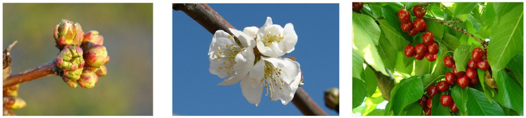

Stages of Cherry

# Chapter 4: Climate Change and impact projection

# 1.1 Drivers of Climate change include:

- Sun: Warms the earth through radiation. It is an important driver of climate change on geological timescales, but not of recent climate change.
- Aerosols: They are largely dusts. Suspensions of liquid, solid, or mixed particles with highly variable chemical composition and size distribution.
- Clouds: Can have both cooling and warming effect.
- Ozone: Surface (tropospheric) ozone: constituent of smog, health hazard (bad ozone). Greenhouse gas: presence in the stratosphere has a warming effect. Destroyed by chlorofluorocarbons (CFCs).
- Surface albedo: Reflection of radiation by the land surface. Light surfaces (e.g. ice, snow) reflect almost all radiation, dark surfaces (ocean, dark soil, forest) very little.
- Greenhouse gases: Atmospheric gases that trap heat on Earth. Greenhouse effects warms the planet.
- Long-term drivers:

## *Exercises on Climate Change*

1. List the main drivers of climate change at the decade to century scale, and briefly explain the mechanism through which the currently most important driver affects our climate.
- Sun
- Aerosols
- Clouds
- Ozone
- Surface albedo
- Greenhouse gases
- Long-term drivers

Most important: **GHGs** **Greenhouse effect** + Raises Earth’s mean temperature: +14°C instead of -18°C without GHGs! + Major GHGs: water vapor, CO2 (carbon dioxide), CH4 (methane), N2O (nitrous oxide)

1. Explain briefly what is special about temperature dynamics of recent decades, and why we have good reasons to be concerned.

Since 1901 strong warming (almost) everywhere on Earth.Up to 8°C warmer than the 2003-2018 average. Precipitation anomalies (relative to median prec.) for Cologne/Bonn weather station. Some years with dry springs/summer.

1. What does the abbreviation ‘RCP’ stand for, how are RCPs defined, and what is their role in projecting future climates? Representative Concentration Pathways (RCPs). It is a new greenhouse forcing scenarios in the IPCC‘s5th Assessment Report. From RCP to inputs for climate change impact models.

1. Briefly describe the 4 climate impact projection methods described in the fourth video.
- Statistical models
- Species distribution modeling
- Process-based models
- Climate analogue analysis

# Chapter 5: Winter Chill Projections

## *Exercises on past chill projections*

1. Sketch out three data access and processing challenges that had to be overcome in order to produce chill projections with state-of-the-art methodology.
- Accessing Climate Data for Specific Locations: Previous climate datasets like AFRICLIM and ClimateWizard only provided large-scale data. To get weather data for specific locations without downloading too much extra information, an API was created to quickly access data for single sites
- Converting Daily to Hourly Temperature Data: Chill models need hourly temperature data, but many databases only give daily averages. Early methods for converting daily to hourly data weren’t very good, especially in areas with unique temperatures. Improved algorithms were developed to estimate hourly temperatures more accurately from daily data
- Handling Large Volumes of Climate Model Outputs: Studying different climate futures involves dealing with a lot of data from many climate models, which can be hard to manage. To handle this large amount of data effectively, workflows were streamlined and selective processing techniques were used
2. Outline, in your understanding, the basic steps that are necessary to make such projections.
- Data Collection and Calibration: collect historical weather data and use it to calibrate a weather generator for realistic temperature simulations
- Model Selection and Scenario Setup: choose relevant climate models and emission scenarios to explore various future climates
- Generate Temperature Projections: downscale climate data, converting it to daily or hourly temperatures as needed for chill calculations
- Chill Calculation: apply chill models to estimate chill accumulation across different climate scenarios
- Analysis and Visualization: compare chill projections across models and scenarios and visualize the findings
- Interpretation: validate projections with observed data where possible and assess agricultural impacts and adaptation needs

# Chapter 6: Manual Chill Analysis

## *Computing Chilling Hours from Hourly Temperature data*

1. Write a basic function that calculates warm hours (>25°C)

# calculate warm hours

WH<-function(hourtemps) { hourtemps[, “Warm_Hour”] <- hourtemps$Temp >= 25

return(hourtemps) }

1. Apply this function to the Winters_hours_gaps dataset

WH(hourtemps)[1:50, ]

sum(hourtemps$Warm_Hour)

1. Extend this function, so that it can take start and end dates as inputs and sums up warm hours between these dates

sum_WH <- function(hourtemps, startYEARMODAHO, endYEARMODAHO)

{hourtemps[,“Warm_Hour”] <- hourtemps$Temp > 25

startYear <- as.numeric(substr(startYEARMODAHO, 1, 4)) startMonth <- as.numeric(substr(startYEARMODAHO, 5, 6)) startDay <- as.numeric(substr(startYEARMODAHO, 7, 8)) startHour <- as.numeric(substr(startYEARMODAHO, 9, 10))

endYear <- as.numeric(substr(endYEARMODAHO, 1, 4)) endMonth <- as.numeric(substr(endYEARMODAHO, 5, 6)) endDay <- as.numeric(substr(endYEARMODAHO, 7, 8)) endHour <- as.numeric(substr(endYEARMODAHO, 9, 10))

Start_Date <- which(hourtemps$Year == startYear & hourtemps$Month == startMonth & hourtemps$Day == startDay & hourtemps$Hour == startHour)

End_Date <- which(hourtemps$Year == endYear & hourtemps$Month == endMonth & hourtemps$Day == endDay & hourtemps$Hour == endHour)

WHs <- sum(hourtemps$Warm_Hour[Start_Date:End_Date]) return(WHs) }

# Example

sum_WH(Winters_hours_gaps, startYEARMODAHO = 2008070100, endYEARMODAHO = 2008073123)

# Chapter 7: Winter Chill Projections

## *Exercises Chill Models*

1. Run the chilling() function on the Winters_hours_gap dataset

July <- chilling(make_JDay(Winters_hours_gaps), Start_JDay = 183, End_JDay = 214)

1. Create your own temperature-weighting chill model using the step_model() function
2. Run this model on the Winters_hours_gaps dataset using the tempResponse() function.

# Chapter 8: Making Hourly Temperatures

## *Exercises on hourly*

1. Choose a location of interest, find out its latitude and produce plots of daily sunrise, sunset and daylength

require(chillR) library(ggplot2) library(tidyr)

# sunset time and daylength at Fayetteville (Latitude: 35.05°N) over the course of the year.

Days <- daylength(latitude = 35, JDay = 1:365) Days_df <- data.frame( JDay = 1:365, Sunrise = Days$Sunrise, Sunset = Days$Sunset, Daylength = Days$Daylength )

Days_df <- pivot_longer(Days_df, cols=c(Sunrise:Daylength))

1. Produce an hourly dataset, based on idealized daily curves, for the KA_weather dataset (included in chillR)

stack_hourly_temps(KA_weather, latitude = 35)

1. Produce empirical temperature curve parameters for the Winters_hours_gaps dataset, and use them to predict hourly values from daily temperatures (this is very similar to the example above, but please make sure you understand what’s going on)

# Chapter 9: Some Useful tools in R

## *Exercises on useful R tools*

1. Based on the Winters_hours_gaps dataset, use magrittr pipes and functions of the tidyverse to accomplish the following:
- Convert the dataset into a tibble
- Select only the top 10 rows of the dataset
- Convert the tibble to a long format, with separate rows for Temp_gaps and Temp
- Use ggplot2 to plot Temp_gaps and Temp as facets (point or line plot)
- Convert the dataset back to the wide format
- Select only the following columns: Year, Month, Day and Temp
- Sort the dataset by the Temp column, in descending order
1. For the Winter_hours_gaps dataset, write a for loop to convert all temperatures (Temp column) to degrees Fahrenheit
2. Execute the same operation with a function from the apply family
3. Now use the tidyverse function mutate to achieve the same outcome
4. Voluntary: consider taking a look at the instruction materials on all these functions, which I linked above, as well as at other sources on the internet. There’s a lot more to discover here, with lots of potential for making your coding more elegant and easier - and possibly even more fun!

# Chapter 10: Getting temperature data

## *Exercises on getting temperature data*

1. Choose a location of interest and find the 25 closest weather stations using the handle_gsod function

library(chillR) station_list_Fayetteville <-handle_gsod(action=“list_stations”, location=c(-78.87, 35.05), time_interval=c(1990,2020)) library(magrittr) require(kableExtra)

kable(station_list) %>% kable_styling(“striped”, position = “left”, font_size = 8)

station_list_Fayetteville

1. Download weather data for the most promising station on the list

weather <- handle_gsod(action = “download_weather”, location = station_list_Fayetteville$chillR_code[4], time_interval = c(1990, 2020))

weather[[1]][1:20,]

1. Convert the weather data into chillR format

cleaned_weather <- handle_gsod(weather)

cleaned_weather[[1]][1:20,]

dir.create(“data”) write.csv(station_list, “data/station_list_Fayetteville.csv”, row.names = FALSE) write.csv(weather[[1]], “data/Fayetteville_weather.csv”, row.names = FALSE) write.csv(cleaned_weather[[1]], “data/Fayetteville_chillR_weather.csv”, row.names = FALSE)

?handle_dwd

handle_dwd(“list_stations”, location = c(-78.87, 35.05))

fix_weather(cleaned_weather[[1]])